# Visualización de datos con ggplot2

Lección práctica (60 minutos)

Autor/a

Informática

Fecha de publicación

22/09/2026

# Plan de la sesión

| Tiempo | Actividad |
| --- | --- |
| 0 – 5 min | Preparación e idea de la “gramática de gráficos” |
| 5 – 15 min | Primer gráfico: `ggplot()`, `aes()` y `geom_point()` |
| 15 – 25 min | Estéticas: color, forma y tamaño · **Ejercicio 1** |
| 25 – 37 min | Otros geoms: histograma, boxplot y barras · **Ejercicio 2** |
| 37 – 47 min | Etiquetas, temas y facetas · **Ejercicio 3** |
| 47 – 57 min | **Ejercicio integrador** |
| 57 – 60 min | Guardar gráficos con `ggsave()` y cierre |

**Objetivo**

Al terminar, podrás construir, personalizar y guardar gráficos con `ggplot2` a partir de un data frame.

**Requisitos previos:** manejo de objetos, vectores y data frames en R.

# 1 Preparación (0 – 5 min)

Instala los paquetes **solo la primera vez** (quita el `#` para ejecutar):

```r
# install.packages("ggplot2")
# install.packages("palmerpenguins")
```

Carga los paquetes y los datos:

```r
library(ggplot2)
library(palmerpenguins)

# Eliminamos las filas con datos faltantes para simplificar
pinguinos <- na.omit(penguins)

head(pinguinos)
```

```
# A tibble: 6 × 8
  species island    bill_length_mm bill_depth_mm flipper_length_mm body_mass_g
  <fct>   <fct>              <dbl>         <dbl>             <int>       <int>
1 Adelie  Torgersen           39.1          18.7               181        3750
2 Adelie  Torgersen           39.5          17.4               186        3800
3 Adelie  Torgersen           40.3          18                 195        3250
4 Adelie  Torgersen           36.7          19.3               193        3450
5 Adelie  Torgersen           39.3          20.6               190        3650
6 Adelie  Torgersen           38.9          17.8               181        3625
# ℹ 2 more variables: sex <fct>, year <int>
```

```r
str(pinguinos)
```

```
tibble [333 × 8] (S3: tbl_df/tbl/data.frame)
 $ species          : Factor w/ 3 levels "Adelie","Chinstrap",..: 1 1 1 1 1 1 1 1 1 1 ...
 $ island           : Factor w/ 3 levels "Biscoe","Dream",..: 3 3 3 3 3 3 3 3 3 3 ...
 $ bill_length_mm   : num [1:333] 39.1 39.5 40.3 36.7 39.3 38.9 39.2 41.1 38.6 34.6 ...
 $ bill_depth_mm    : num [1:333] 18.7 17.4 18 19.3 20.6 17.8 19.6 17.6 21.2 21.1 ...
 $ flipper_length_mm: int [1:333] 181 186 195 193 190 181 195 182 191 198 ...
 $ body_mass_g      : int [1:333] 3750 3800 3250 3450 3650 3625 4675 3200 3800 4400 ...
 $ sex              : Factor w/ 2 levels "female","male": 2 1 1 1 2 1 2 1 2 2 ...
 $ year             : int [1:333] 2007 2007 2007 2007 2007 2007 2007 2007 2007 2007 ...
 - attr(*, "na.action")= 'omit' Named int [1:11] 4 9 10 11 12 48 179 219 257 269 ...
  ..- attr(*, "names")= chr [1:11] "4" "9" "10" "11" ...
```

Los datos contienen mediciones de **333 pingüinos** de tres especies (*Adelie*, *Chinstrap* y *Gentoo*) en tres islas del archipiélago Palmer, Antártida.

| Variable | Descripción |
| --- | --- |
| `species` | Especie |
| `island` | Isla |
| `bill_length_mm` | Longitud del pico (mm) |
| `bill_depth_mm` | Profundidad del pico (mm) |
| `flipper_length_mm` | Longitud de la aleta (mm) |
| `body_mass_g` | Masa corporal (g) |
| `sex` | Sexo |
| `year` | Año de muestreo |

## 1.1 La gramática de gráficos

Todo gráfico de `ggplot2` se construye **por capas** con la misma estructura:

```r
ggplot(data = <DATOS>, mapping = aes(<MAPEOS>)) +
  <GEOM_FUNCIÓN>() +
  <OTRAS CAPAS>
```

- **Datos**: el data frame.
- **Estéticas (`aes`)**: qué variable va en el eje x, eje y, color, forma…
- **Geometrías (`geom_*`)**: cómo se dibujan los datos (puntos, barras, líneas…).
- Las capas se suman con **`+`**.

# 2 Primer gráfico (5 – 15 min)

## 2.1 Paso a paso

Solo los datos: un lienzo vacío.

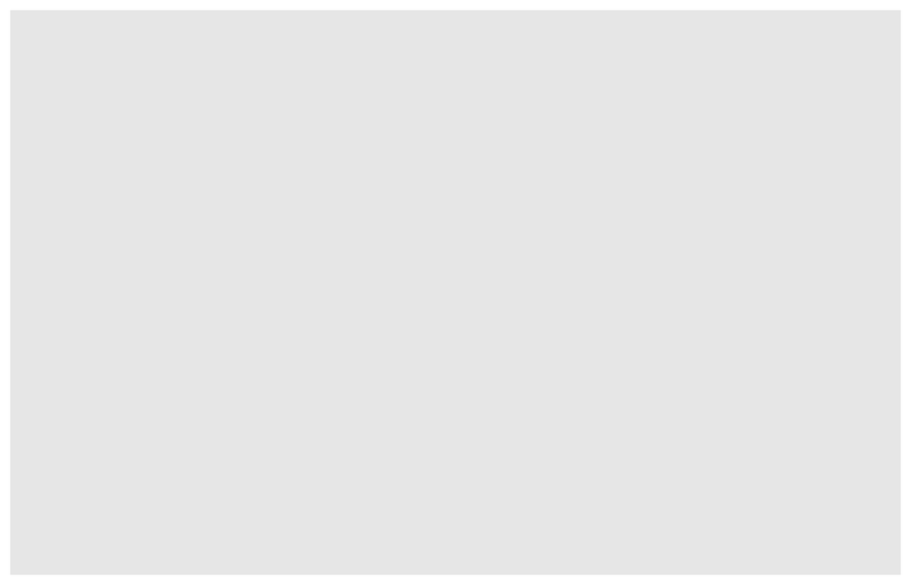

```r
ggplot(data = pinguinos)
```

Agregamos los ejes con `aes()`:

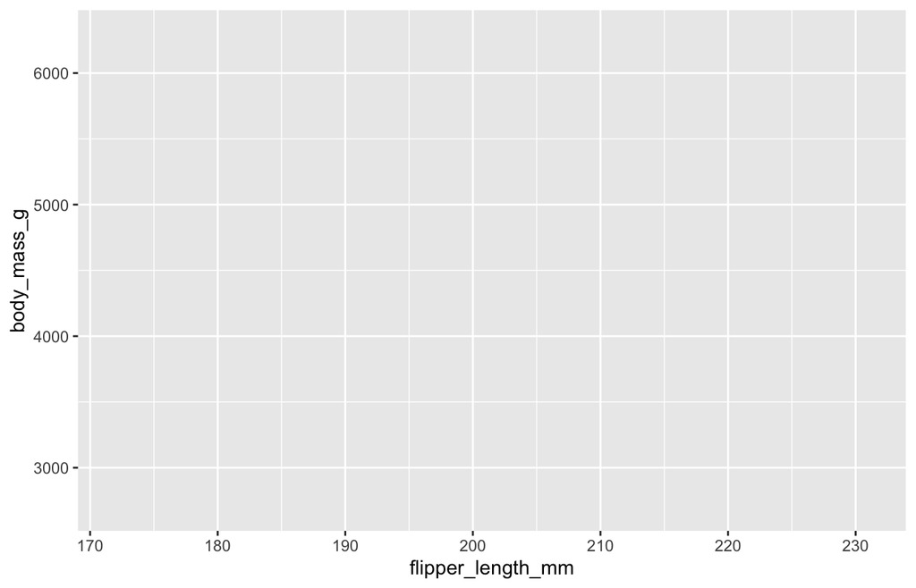

```r
ggplot(data = pinguinos, mapping = aes(x = flipper_length_mm, y = body_mass_g))
```

Agregamos una geometría: puntos.

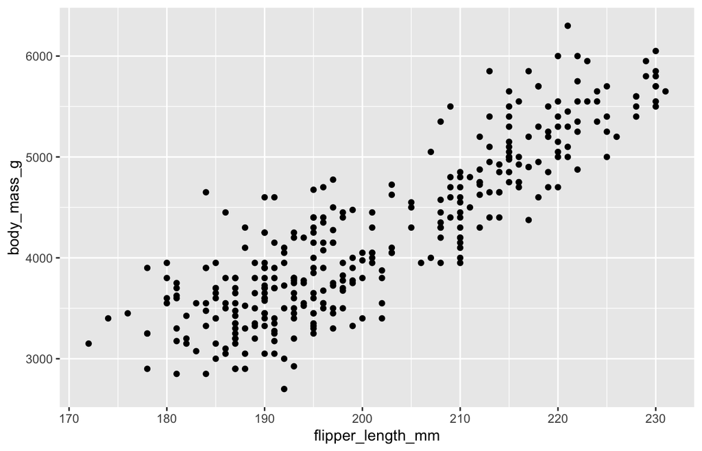

```r
ggplot(data = pinguinos, mapping = aes(x = flipper_length_mm, y = body_mass_g)) +
  geom_point()
```

**Pregunta**

¿Qué relación observas entre la longitud de la aleta y la masa corporal?

## 2.2 Forma abreviada

Es común omitir los nombres `data =` y `mapping =`:

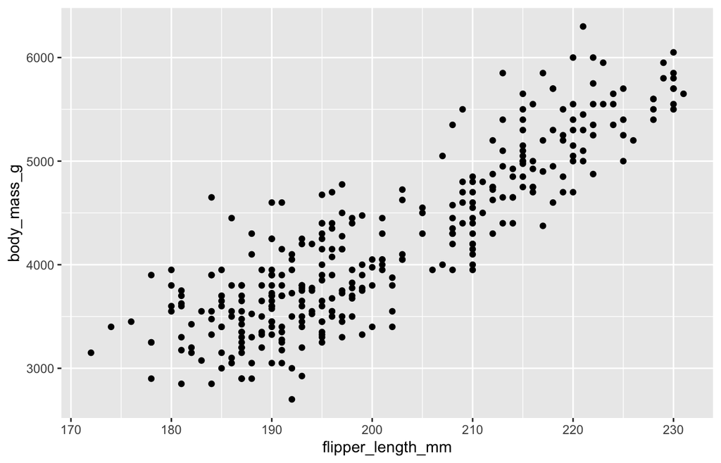

```r
ggplot(pinguinos, aes(x = flipper_length_mm, y = body_mass_g)) +
  geom_point()
```

## 2.3 Agregar una línea de tendencia

Las capas se apilan. `geom_smooth(method = "lm")` agrega una recta de regresión:

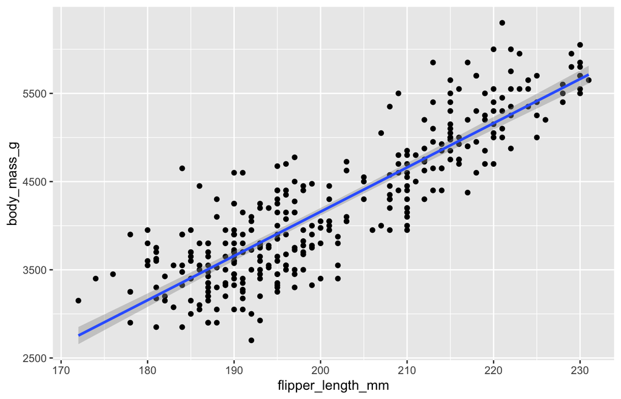

```r
ggplot(pinguinos, aes(x = flipper_length_mm, y = body_mass_g)) +
  geom_point() +
  geom_smooth(method = "lm")
```

# 3 Estéticas: color, forma y tamaño (15 – 25 min)

## 3.1 Mapear una variable a una estética

Si la estética va **dentro** de `aes()`, depende de una variable:

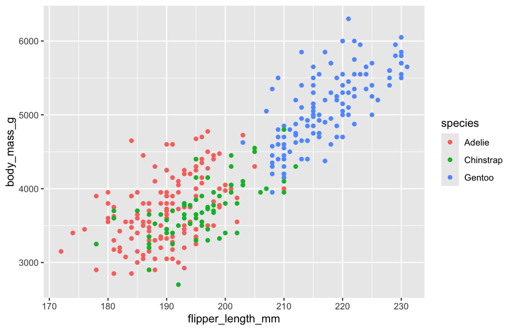

```r
ggplot(pinguinos, aes(x = flipper_length_mm, y = body_mass_g, color = species)) +
  geom_point()
```

Podemos combinar varias estéticas:

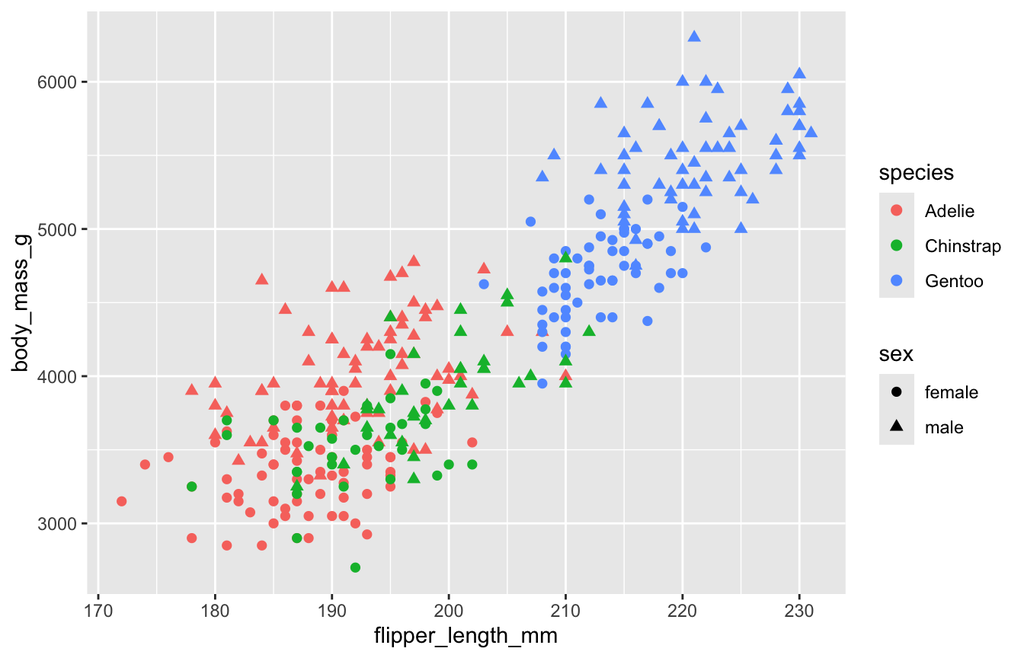

```r
ggplot(pinguinos, aes(x = flipper_length_mm, y = body_mass_g,
                      color = species, shape = sex)) +
  geom_point(size = 2)
```

## 3.2 Fijar una estética

Si la estética va **fuera** de `aes()` (dentro del `geom`), se aplica igual a todos los puntos:

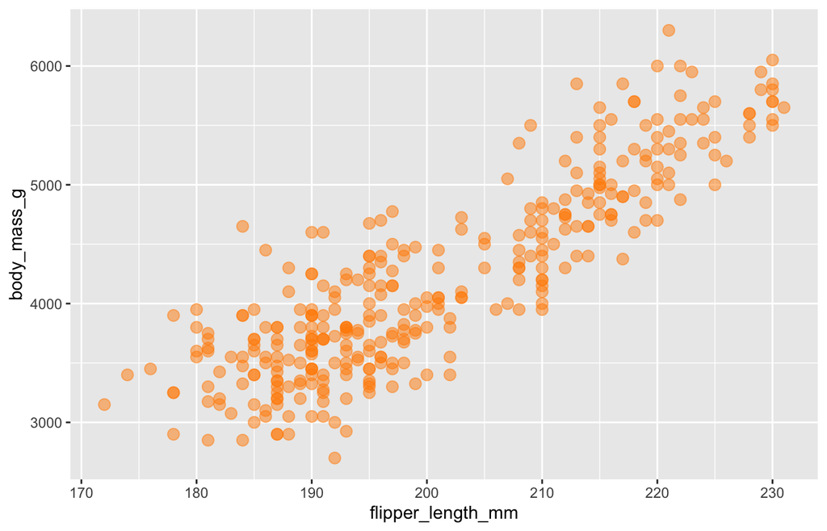

```r
ggplot(pinguinos, aes(x = flipper_length_mm, y = body_mass_g)) +
  geom_point(color = "darkorange", size = 3, alpha = 0.5)
```

**Nota**

`alpha` controla la transparencia (0 = invisible, 1 = opaco). Es útil cuando hay muchos puntos encimados.

## 3.3 Error común

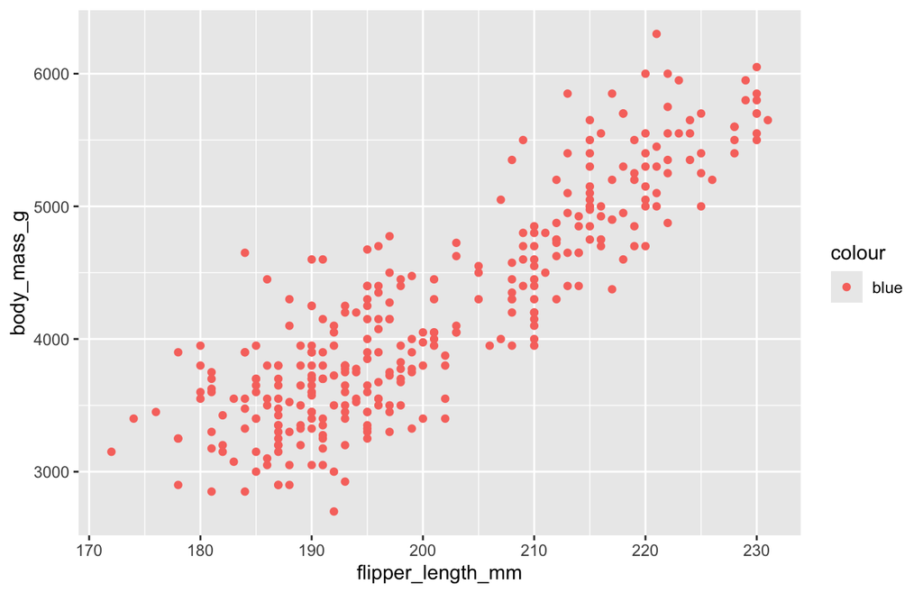

```r
# ¿Por qué los puntos NO salen azules?
ggplot(pinguinos, aes(x = flipper_length_mm, y = body_mass_g, color = "blue")) +
  geom_point()
```

**Advertencia**

Dentro de `aes()`, `"blue"` se interpreta como una *categoría* llamada “blue”, no como un color. El color fijo debe ir dentro de `geom_point()`.

## 3.4 Ejercicio 1 (≈ 5 min)

**Ejercicio 1**

Crea un diagrama de dispersión con la **longitud del pico** (`bill_length_mm`) en el eje x y la **profundidad del pico** (`bill_depth_mm`) en el eje y.

1. Colorea los puntos por **especie**.
2. Usa una forma distinta según la **isla**.
3. Haz los puntos de tamaño 3 y con transparencia de 0.7.

```r
ggplot(pinguinos, aes(x = ___, y = ___, color = ___, shape = ___)) +
  geom_point(size = ___, alpha = ___)
```

# 4 Otras geometrías (25 – 37 min)

El tipo de gráfico depende del **tipo de variable**:

| Pregunta | Variables | Geom |
| --- | --- | --- |
| ¿Cómo se distribuye una variable numérica? | 1 numérica | `geom_histogram()`, `geom_density()` |
| ¿Cómo se compara entre grupos? | 1 categórica + 1 numérica | `geom_boxplot()`, `geom_violin()` |
| ¿Cuántos hay en cada categoría? | 1 categórica | `geom_bar()` |
| ¿Cómo se relacionan dos variables? | 2 numéricas | `geom_point()` |

## 4.1 Histograma

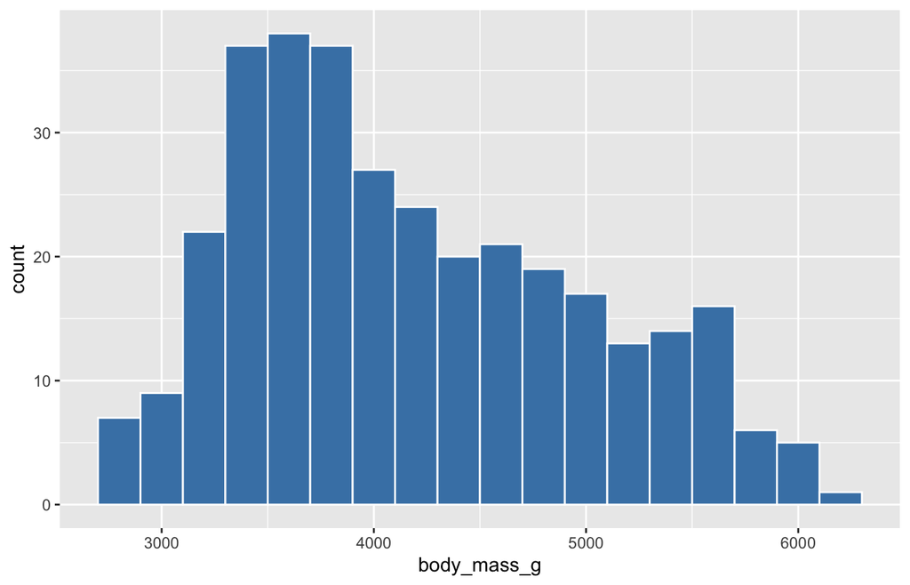

```r
ggplot(pinguinos, aes(x = body_mass_g)) +
  geom_histogram(binwidth = 200, fill = "steelblue", color = "white")
```

Por especie (usamos `fill` para el relleno):

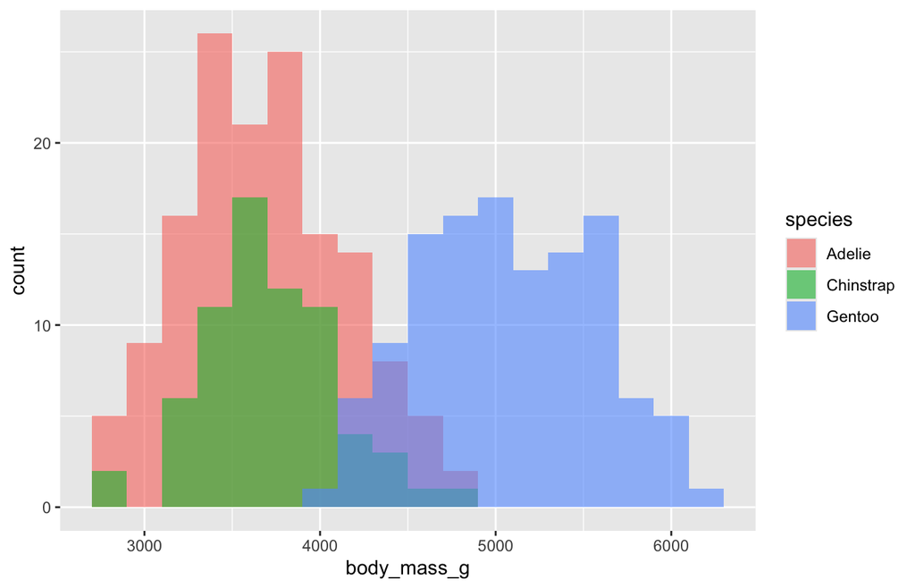

```r
ggplot(pinguinos, aes(x = body_mass_g, fill = species)) +
  geom_histogram(binwidth = 200, alpha = 0.6, position = "identity")
```

## 4.2 Densidad

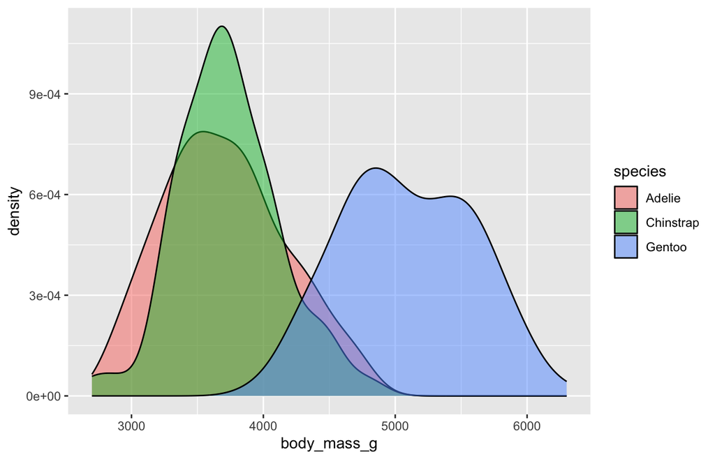

```r
ggplot(pinguinos, aes(x = body_mass_g, fill = species)) +
  geom_density(alpha = 0.5)
```

## 4.3 Diagrama de caja (boxplot)

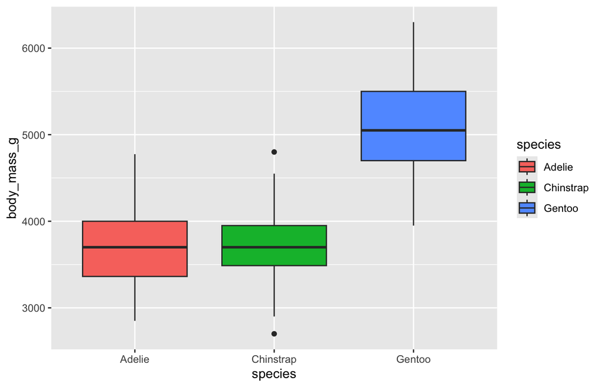

```r
ggplot(pinguinos, aes(x = species, y = body_mass_g, fill = species)) +
  geom_boxplot()
```

Combinando capas: cajas + puntos individuales con `geom_jitter()`.

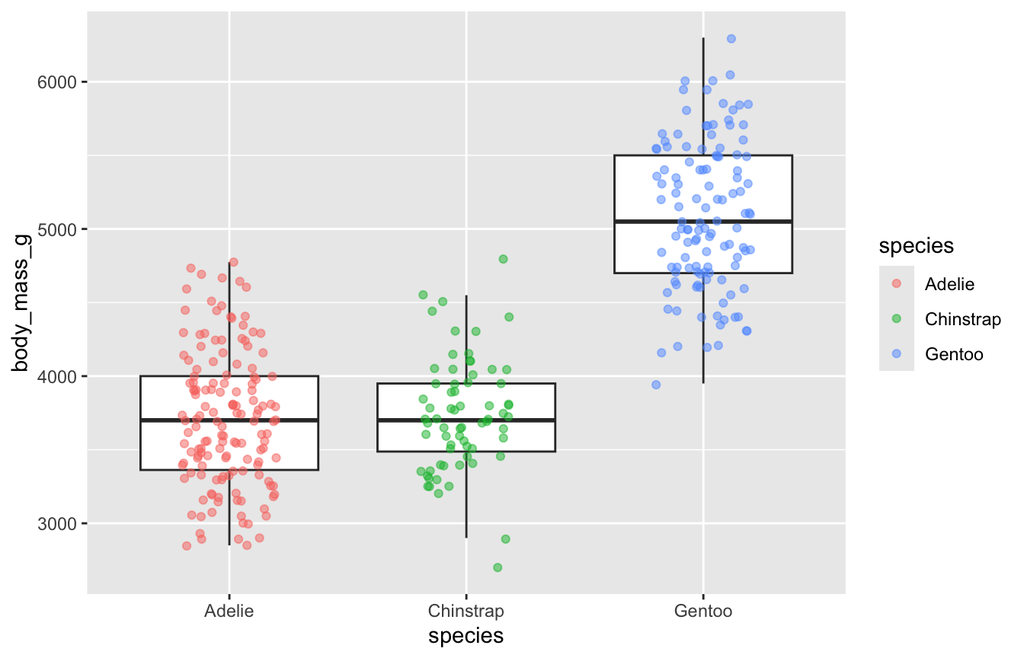

```r
ggplot(pinguinos, aes(x = species, y = body_mass_g)) +
  geom_boxplot(outlier.shape = NA) +
  geom_jitter(aes(color = species), width = 0.2, alpha = 0.5)
```

## 4.4 Gráfico de barras

`geom_bar()` **cuenta** automáticamente las observaciones de cada categoría:

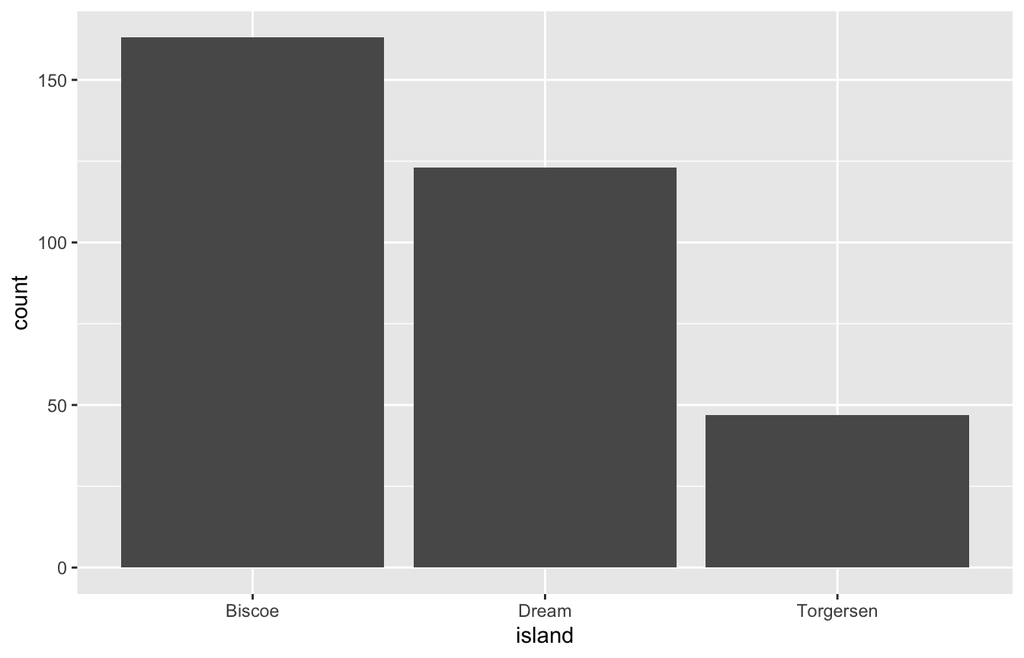

```r
ggplot(pinguinos, aes(x = island)) +
  geom_bar()
```

Barras apiladas y agrupadas por especie:

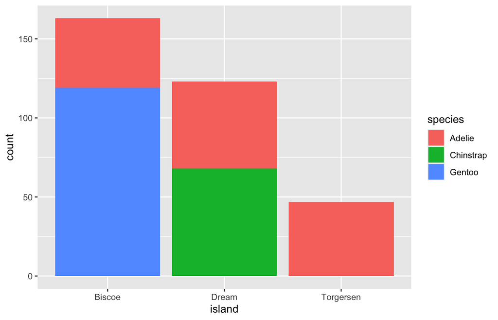

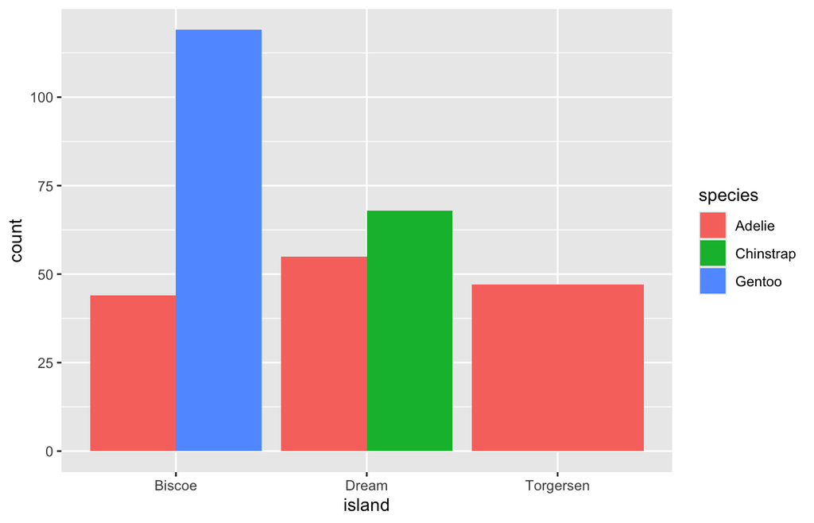

```r
ggplot(pinguinos, aes(x = island, fill = species)) +
  geom_bar()                       # apiladas (por defecto)
ggplot(pinguinos, aes(x = island, fill = species)) +
  geom_bar(position = "dodge")     # una al lado de la otra
```

**Pregunta**

¿Qué especie se encuentra en las tres islas?

## 4.5 Ejercicio 2 (≈ 5 min)

**Ejercicio 2**

1. Haz un **boxplot** de la longitud de la aleta (`flipper_length_mm`) por **especie**, con el relleno según el **sexo**.
2. Haz un **gráfico de barras** del número de pingüinos por **especie**, con las barras rellenas según el **sexo** y colocadas una al lado de la otra.

```r
# a)
ggplot(pinguinos, aes(x = ___, y = ___, fill = ___)) +
  geom_____()

# b)
ggplot(pinguinos, aes(x = ___, fill = ___)) +
  geom_bar(position = ___)
```

# 5 Etiquetas, temas y facetas (37 – 47 min)

## 5.1 Etiquetas con `labs()`

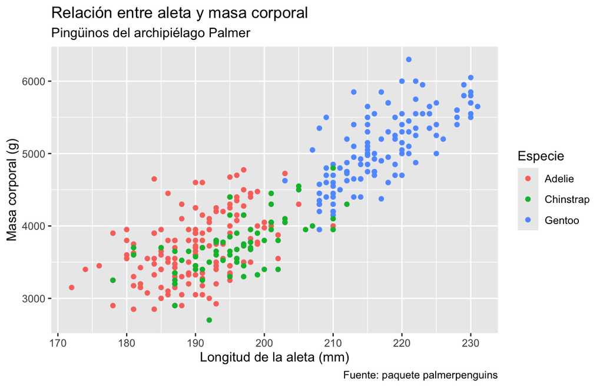

```r
ggplot(pinguinos, aes(x = flipper_length_mm, y = body_mass_g, color = species)) +
  geom_point() +
  labs(
    title    = "Relación entre aleta y masa corporal",
    subtitle = "Pingüinos del archipiélago Palmer",
    x        = "Longitud de la aleta (mm)",
    y        = "Masa corporal (g)",
    color    = "Especie",
    caption  = "Fuente: paquete palmerpenguins"
  )
```

## 5.2 Temas

Los temas cambian la apariencia general (fondo, cuadrícula, tipografía):

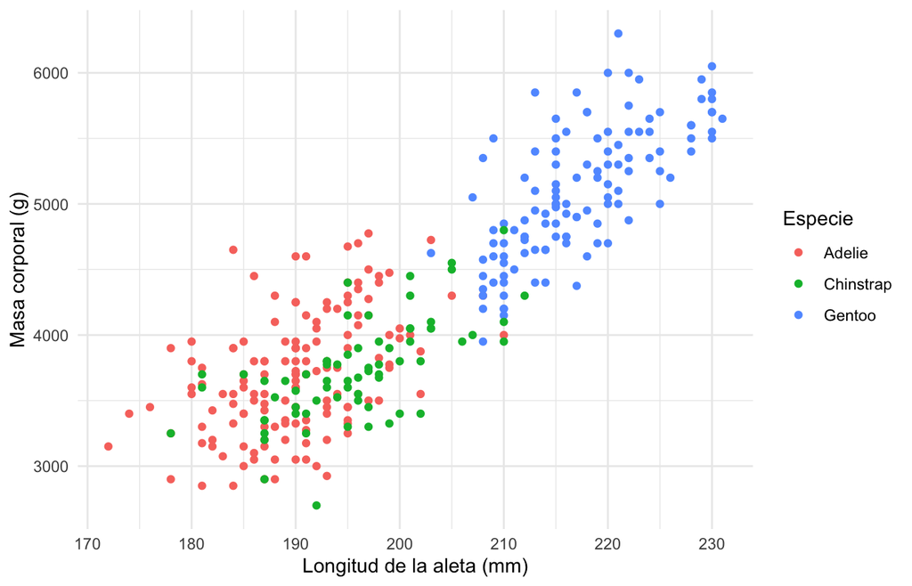

```r
g <- ggplot(pinguinos, aes(x = flipper_length_mm, y = body_mass_g, color = species)) +
  geom_point() +
  labs(x = "Longitud de la aleta (mm)", y = "Masa corporal (g)", color = "Especie")

g + theme_minimal()
```

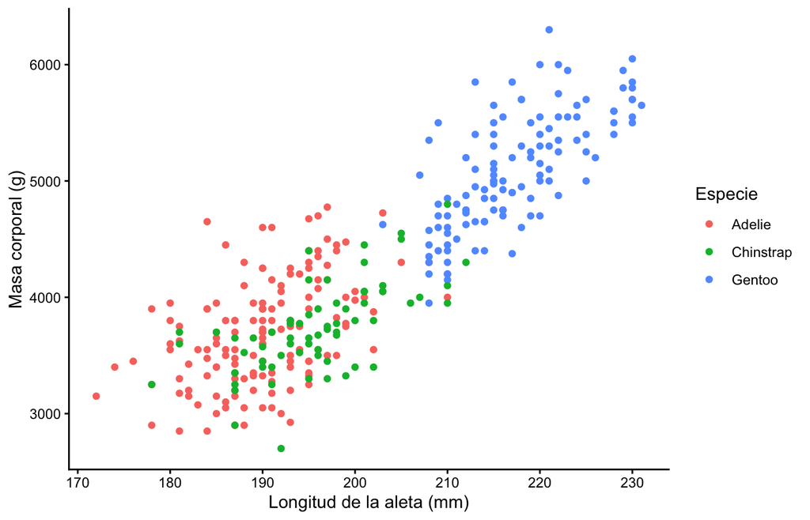

```r
g + theme_classic()
```

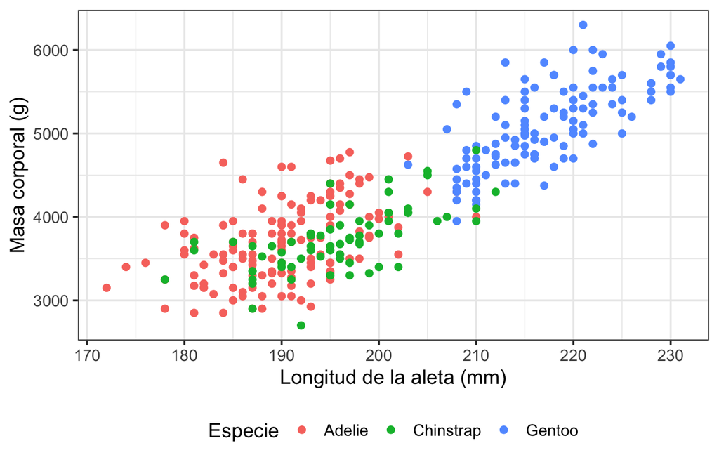

```r
g + theme_bw(base_size = 14) + theme(legend.position = "bottom")
```

**Nota**

Un gráfico se puede **guardar en un objeto** (`g`) y luego agregarle capas.

## 5.3 Colores manuales

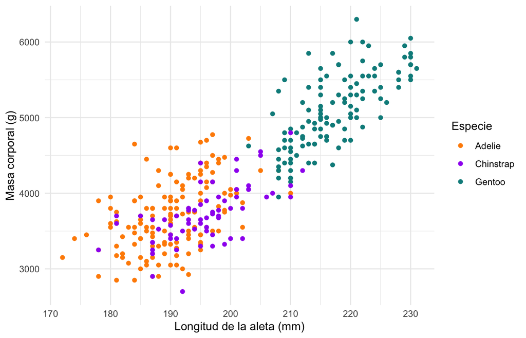

```r
g + scale_color_manual(values = c("Adelie"    = "darkorange",
                                  "Chinstrap" = "purple",
                                  "Gentoo"    = "cyan4")) +
  theme_minimal()
```

## 5.4 Facetas

Las facetas dividen el gráfico en paneles según una variable categórica:

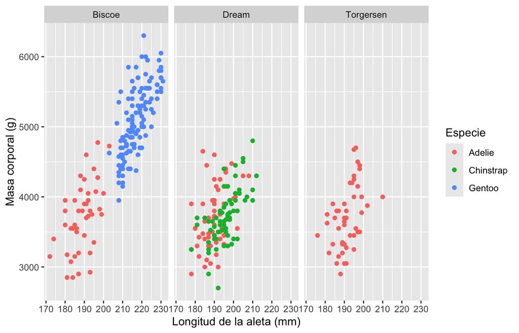

```r
g + facet_wrap(~ island)
```

Con dos variables se usa `facet_grid(filas ~ columnas)`:

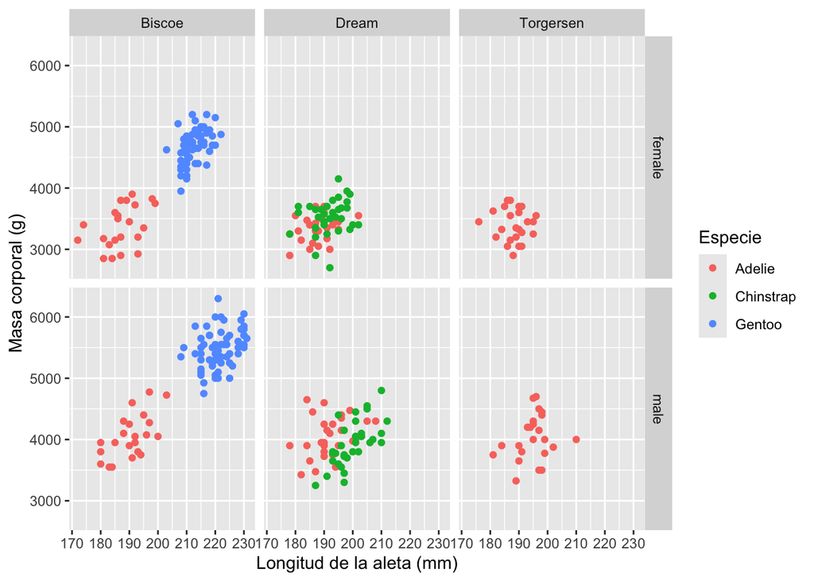

```r
g + facet_grid(sex ~ island)
```

## 5.5 Ejercicio 3 (≈ 5 min)

**Ejercicio 3**

Partiendo del boxplot del ejercicio 2a:

1. Agrega un título y cambia los nombres de los ejes y de la leyenda al español.
2. Aplica `theme_minimal()`.
3. Divide el gráfico en paneles por **isla** con `facet_wrap()`.

```r
ggplot(pinguinos, aes(x = species, y = flipper_length_mm, fill = sex)) +
  geom_boxplot() +
  labs(title = ___, x = ___, y = ___, fill = ___) +
  theme_____() +
  facet_wrap(~ ___)
```

# 6 Ejercicio integrador (47 – 57 min)

**Ejercicio integrador**

Construye un gráfico que cumpla con lo siguiente:

1. Eje x: longitud del pico; eje y: profundidad del pico.
2. Puntos coloreados por especie, tamaño 2 y transparencia 0.6.
3. Una recta de regresión **por especie** (`geom_smooth(method = "lm", se = FALSE)`).
4. Paneles separados por **sexo**.
5. Título, ejes y leyenda en español.
6. Un tema de tu elección con la leyenda en la parte inferior.

**Pregunta de reflexión**

Si ignoras la especie, ¿la relación entre la longitud y la profundidad del pico es positiva o negativa? ¿Y dentro de cada especie? (Pista: haz el gráfico con y sin `color = species`.) Este fenómeno se conoce como **paradoja de Simpson**.

```r
# Escribe aquí tu código
```

# 7 Guardar gráficos y cierre (57 – 60 min)

`ggsave()` guarda el **último gráfico** mostrado, o el que indiques con `plot =`:

```r
mi_grafico <- ggplot(pinguinos, aes(x = species, y = body_mass_g, fill = species)) +
  geom_boxplot() +
  theme_minimal()

ggsave("masa_por_especie.png", plot = mi_grafico,
       width = 16, height = 10, units = "cm", dpi = 300)
```

## 7.1 Resumen

- `ggplot(datos, aes(...))` define los datos y los mapeos.
- Los `geom_*()` dibujan: `geom_point`, `geom_histogram`, `geom_boxplot`, `geom_bar`, `geom_smooth`…
- Estéticas **dentro** de `aes()` dependen de una variable; **fuera**, son fijas.
- `labs()`, `theme_*()`, `scale_*()` y `facet_*()` personalizan el gráfico.
- Las capas se suman con `+` y un gráfico se puede guardar en un objeto.
- `ggsave()` exporta el gráfico a un archivo.

## 7.2 Para seguir aprendiendo

- *R for Data Science* (2ª ed.), capítulo de visualización: https://r4ds.hadley.nz/
- Hoja de referencia de ggplot2: https://rstudio.github.io/cheatsheets/html/data-visualization.html
- Galería de extensiones: https://exts.ggplot2.tidyverse.org/gallery/